# Citaciones a mujeres en Cs Sociales Conicet

6/4/2022

## R Markdown

```r
library(data.table)
library(stargazer)
```

```r
library(foreign)
library(igraph)
library(tidyverse)
library(plyr)
library(sqldf)
library(readxl)
library(knitr)
library(DT)
library(highcharter)
library(see)
library(ggsci)
library(hrbrthemes)
library(viridis)
library(gridExtra)
library(haven)
library(sknifedatar)
library(tidyverse)
library(readr)
```

```r
rm(list = ls())
autores_citas <- read_excel("D:/Guada/Research/Computational Social Science/scientific-networks-g/01_data/01_raw/autores_citas (1).xlsx")
```

```
## * `` -> ...8
## * `` -> ...9
```

```r
autores_citas <- autores_citas %>%
  select(author=author, citas_totales, author_genero=genero) %>%
  filter(!is.na(author_genero))
data1 <- read.dta("C:/Users/guada/OneDrive/Escritorio/apellidos_corregidos_stata_viejo.dta")
data1 <- data1 %>% dplyr::rename(investigador_genero=Genero)
data_investigadores <- read_dta("https://github.com/guadag12/antiestablishment_party/raw/main/data/Comunidades_keywords.dta")
data_doctorados_investigadores <- read_csv("https://raw.githubusercontent.com/guadag12/antiestablishment_party/main/data/data_doctorados_investigadores_07042022%20-%20union-lugar_doctorado.csv")
data1 <- data1 %>%
  left_join(data_doctorados_investigadores[, c("idInvestigador", "Lugar")])
#data_investigadores <- read_csv("D:/Guada/Research/Computational Social Science/scientific-networks-g/01_data/01_raw/data_investigadores.csv")
```

```r
data1 <- data1[order(data1$Investigador),]
data11<- data1[data1$test>1,]
data_investigadores <- data_investigadores %>% select(idInvestigador, Comunidad)
data11 <- data11 %>% left_join(data_investigadores, by = "idInvestigador")
data11 <- data11 %>% select(-investigador)
data11$author <- tolower(data11$author)
data11 <- data11 %>%
  mutate(id_art = paste0(idInvestigadorST, "_", articulo))

autores_citas$author <- tolower(autores_citas$author)
autores_citas$author_genero <- toupper(autores_citas$author_genero)

#autores_citas <- autores_citas %>% rename(author = author, author_genero =genero_g)
data10 <- data11 %>%
 left_join(autores_citas, by = c("author" = "author"))

data11 <- data11 %>%
 left_join(autores_citas, by = c("author" = "author"))

data11 <- data11 %>%
  filter(!is.na(author_genero) & !is.na(investigador_genero)) %>%
   mutate(Comunidad = case_when(
     Comunidad == 1 ~ 1, Comunidad == 2 ~ 2,
     Comunidad == 4 ~ 3, Comunidad == 6 ~ 4,
     Comunidad == 7 ~ 5, Comunidad == 9 ~ 6,
     T ~ 7))

#data11 <- data11 %>% left_join(data_investigadores, by = "idInvestigador")

data12 <- data11 %>%
   filter(!is.na(author_genero) & !is.na(investigador_genero)) %>%
   select(id_art, investigador_genero, author_genero) %>%
 mutate(author_genero = case_when(
   author_genero == "F" ~ 1,
   T ~ 0
   ))

data_cita <-  data.table(data12)[, cita_muj := if(sum(author_genero) >= 1) 1 else 0, by = id_art]
```

```r
data111 <- sqldf("select id_art, author_genero, investigador_genero, count(*) cantidad from data11 group by id_art, author_genero, investigador_genero")

data111 <- data111 %>%
  mutate(investigador_genero = case_when(
    investigador_genero == 0 ~ "M",
    T ~ "F"
  )) %>%
  tidyr::spread(key = author_genero, value = cantidad ) %>%
  select(-"ND", Fem ="F", Mas = "M") %>%
  mutate(Fem = as.character(Fem),
         Mas = as.character(Mas))

data111[is.na(data111$Fem), "Fem"] <-0
data111[is.na(data111$Mas), "Mas"] <-0
data111 <- data111 %>%
  gather(key = "author_genero", "cantidad", c(Fem:Mas)) %>%
  arrange(id_art)
```

## Datos 💾

Fueron analizados 1335 autores, de las cuales 342 (25.62 %) son mujeres. Y 253 investigadores, dentro de los cuales hay 123 mujeres.

De los 759 papers evaluados, al menos 479 tienen una autora mujer entre sus citas. Si bien es un número interesante, recordemos que sólo tenemos el género de 1335, (39.5%) autores, de un total de 3380 autores.

# Boxplot 📏

```r
data_perc <-  data111 %>%#
  group_by(id_art,investigador_genero) %>%
  dplyr::summarise(author_genero = author_genero,
                   cantidad = as.numeric(cantidad),
                   percent = cantidad/sum(cantidad)) %>%
  filter(!is.na(percent))
```

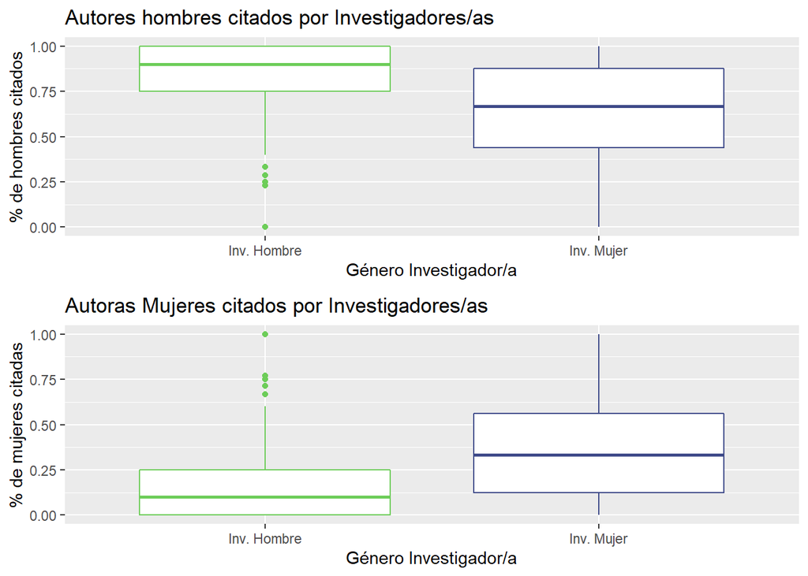

```r
wrap_names <- c(`M` = "Inv. Hombres", `F` = "Inv. Mujeres")

p1 <- data_perc %>%
  filter(author_genero == "Mas") %>%
  mutate(investigador_genero = case_when(investigador_genero == "F" ~ "Inv. Mujer", T ~ "Inv. Hombre")) %>%
  ggplot( aes(x=investigador_genero, y=percent, color = investigador_genero)) +
    geom_boxplot() +
  ggtitle("Autores hombres citados por Investigadores/as") +
  ylab("% de hombres citados") +
  xlab("Género Investigador/a")+
  theme(legend.position = "none") +
      scale_color_manual(values=c( "#6DCD59","#3E4A89"))


p2 <- data_perc %>%
  filter(author_genero == "Fem") %>%
  mutate(investigador_genero = case_when(investigador_genero == "F" ~ "Inv. Mujer", T ~ "Inv. Hombre")) %>%
  ggplot( aes(x=investigador_genero, y=percent, color = investigador_genero)) +
  geom_boxplot() +
  ggtitle("Autoras Mujeres citados por Investigadores/as") +
  ylab("% de mujeres citadas") +
  xlab("Género Investigador/a") +
  theme(legend.position = "none") +
      scale_color_manual(values=c("#6DCD59","#3E4A89"))


grid.arrange(p1, p2)
```

```r
ddd <- data111 %>%
  mutate(cantidad = as.numeric(cantidad)) %>%
  group_by(investigador_genero, author_genero) %>%
  dplyr::summarise(suma = sum(cantidad)) %>%
  ungroup() %>%
  group_by(investigador_genero) %>%
  dplyr::mutate(perc = paste0(round((suma/sum(suma))*100,2), "%")) %>%
  dplyr::rename(`Genero autor/a` = author_genero) %>%
  mutate(investigador_genero = case_when(
    investigador_genero == "M" ~ "Masculino",
    T ~ "Femenino"),
    `Genero autor/a` = case_when(
    `Genero autor/a` == "Mas" ~ "Masculino",
    T ~ "Femenino")
    )
```

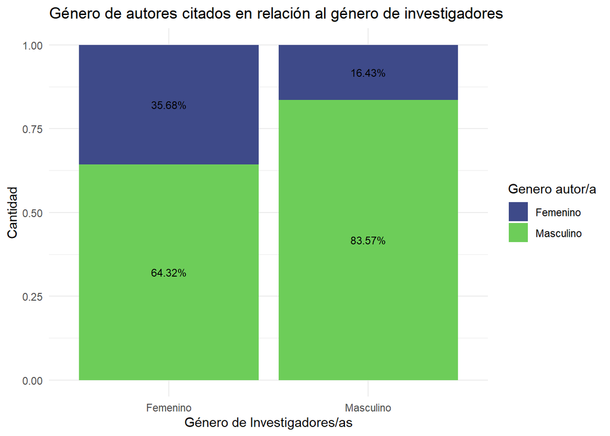

```r
ggplot(ddd) +
  aes(x = investigador_genero, y = suma, fill = `Genero autor/a` ) +
  geom_bar(stat = "identity", position = "fill") +
  theme_minimal() +
  xlab("Género de Investigadores/as") +
  ylab("Cantidad") +
  scale_fill_manual(values=c( "#3E4A89","#6DCD59")) +
  geom_text(aes(label=perc, group=`Genero autor/a`),size=3,
            position = position_fill(vjust=0.5), ddd) +
  ggtitle("Género de autores citados en relación al género de investigadores")
```

# Insights 💡

### Distribución en la citación 🔎

```r
require('plyr')
comu_names <-  c(`1` = "1) Socio. Política", `2` = "2) Socio. Rural y Demografia", `3` = "3) Instituciones Políticas",
                              `4` = "4) Teoria Social", `5` = "5) Movimientos Sociales", `6` = "6) Estudios Culturales",
                              `7` = "7) Comunicación y Salud")

data_perc1 <- data_perc %>%
  left_join(data11 %>%
            mutate(id_art = paste0(idInvestigadorST, "_", articulo)) %>%
            select(id_art, Comunidad), by = "id_art") %>%
  mutate(Comunidad = case_when(
     Comunidad == 1 ~ 1, Comunidad == 2 ~ 2,
     Comunidad == 4 ~ 3, Comunidad == 6 ~ 4,
     Comunidad == 7 ~ 5, Comunidad == 9 ~ 6,
     T ~ 7))

data_perc2 <- data_perc %>%
  left_join(data11 %>%
            mutate(id_art = paste0(idInvestigadorST, "_", articulo)) %>%
            select(id_art, disciplina), by = "id_art") %>%
  mutate(disciplina = case_when(disciplina == "Derecho,Cs.Políticas y Relaciones Internacionales" ~ "Derecho, CP y RRII",
                                T ~ "Sociología, CS y Demografía"))
data_perc3 <- data_perc %>%
  left_join(data11 %>%
            mutate(id_art = paste0(idInvestigadorST, "_", articulo)) %>%
            select(id_art, categoria), by = "id_art")

data_perc4 <- data_perc %>%
  left_join(data11 %>%
            mutate(id_art = paste0(idInvestigadorST, "_", articulo)) %>%
            select(id_art, gruposetarios), by = "id_art")

data_perc5 <- data_perc %>%
  left_join(data11 %>%
            mutate(id_art = paste0(idInvestigadorST, "_", articulo),
                   Lugar = toupper(Lugar)) %>%
            select(id_art, Lugar)
              , by = "id_art") %>%
  filter(!is.na(Lugar))
```

```r
#xaringanExtra::use_panelset()
```

```r
# data_plot <- tibble::tibble(ID = c("Distribución de Probabilidad 📊",
#                                    "Género 🚻",
#                                    "Comunidad 🕸",
#                                    "Disciplina 🎓",
#                                    "Categoría CONICET 🧪",
#                                    "Edad 📅",
#                                    "Lugar PhD 🌐️"),
#                             plots = list(
```

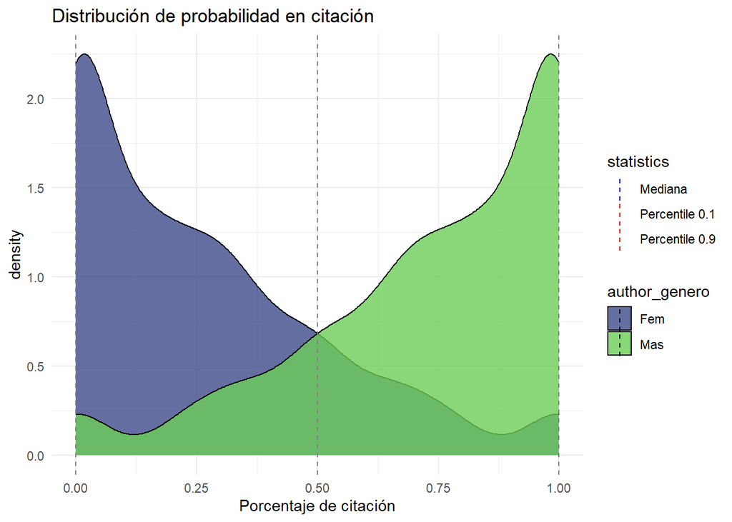

```r
##################################### GENERAL
data_perc %>%
  ggplot(aes(x=percent, group=author_genero, fill=author_genero)) +
  geom_density(alpha=0.8) +
  scale_fill_manual(values=c("#3E4A89", "#6DCD59")) +
  labs(title = "Distribución de probabilidad en citación", x = "Porcentaje de citación") +
  geom_vline(aes(xintercept = median(percent), color="red"), linetype="dashed", show_guide=TRUE) +
  geom_vline(aes(xintercept = quantile(percent,0.1), color="blue"), linetype="dashed", show_guide=TRUE) +
  geom_vline(aes(xintercept = quantile(percent,0.9), color="red"),linetype="dashed", show_guide=TRUE) +
  theme_minimal() +
   scale_color_manual(name = "statistics", values = c("Mediana" = "blue", "Percentile 0.1" = "red", "Percentile 0.9" = "red"))
```

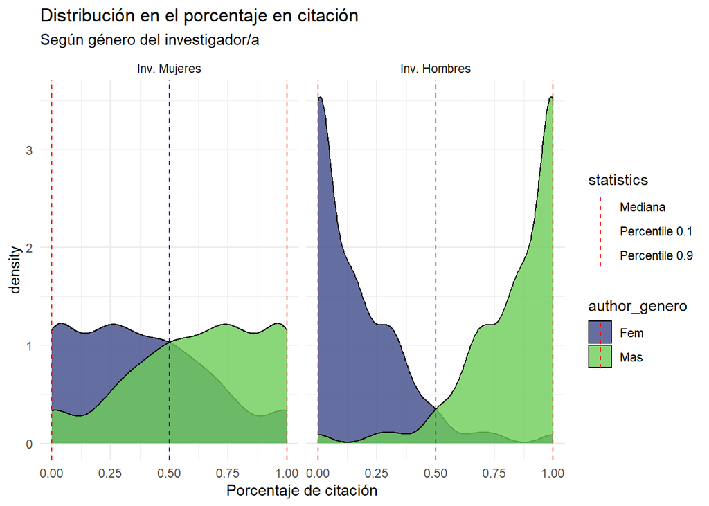

```r
##################################### GENERO
data_perc %>%
  ggplot(aes(x=percent, group=author_genero, fill=author_genero)) +
  geom_density(alpha=0.8) +
  facet_wrap(~investigador_genero, labeller = as_labeller(wrap_names)) +
      scale_fill_manual(values=c("#3E4A89", "#6DCD59")) +
  labs(title = "Distribución en el porcentaje en citación", x = "Porcentaje de citación",
       subtitle = "Según género del investigador/a") +
  geom_vline(data = ddply(data_perc, "investigador_genero", summarize, wavg = median(percent)), aes(xintercept=wavg), color="blue",  linetype="dashed", show_guide=TRUE) +
  geom_vline(data = ddply(data_perc, "investigador_genero", summarize, wavg = quantile(percent,0.1)), aes(xintercept=wavg), color="red", linetype="dashed", show_guide=TRUE) +
  geom_vline(data = ddply(data_perc, "investigador_genero", summarize, wavg = quantile(percent,0.9)), aes(xintercept=wavg), color="red", linetype="dashed", show_guide=TRUE) +
  theme_minimal() +
   scale_color_manual(name = "statistics", values = c("Mediana" = "blue", "Percentile 0.1" = "red", "Percentile 0.9" = "red"))
```

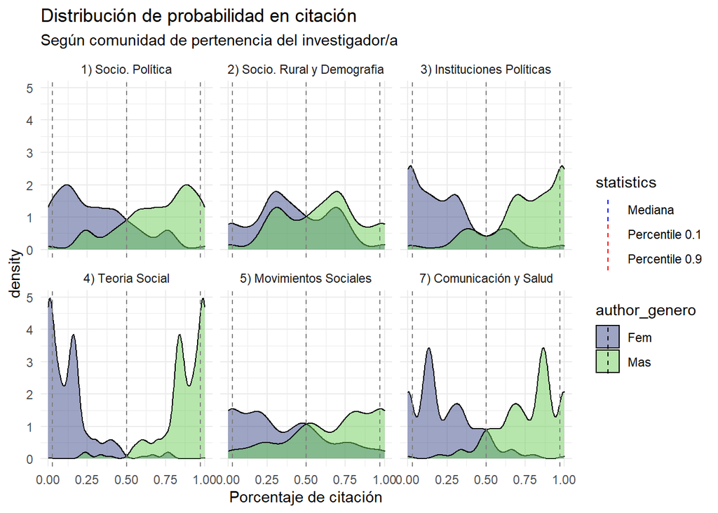

```r
##################################### COMUNIDAD
data_perc1 %>%
  ggplot(aes(x=percent, group=author_genero, fill=author_genero)) +
  geom_density(alpha=0.5) +
  facet_wrap(~Comunidad, labeller = as_labeller(comu_names)
             ) +
  scale_fill_manual(values=c("#3E4A89", "#6DCD59")) +
  labs(title = "Distribución de probabilidad en citación", x = "Porcentaje de citación",
       subtitle = "Según comunidad de pertenencia del investigador/a") +
  geom_vline(aes(xintercept = median(percent), color="red"), linetype="dashed", show_guide=TRUE) +
  geom_vline(aes(xintercept = quantile(percent,0.1), color="blue"), linetype="dashed", show_guide=TRUE) +
  geom_vline(aes(xintercept = quantile(percent,0.9), color="red"),linetype="dashed", show_guide=TRUE) +
  theme_minimal() +
   scale_color_manual(name = "statistics", values = c("Mediana" = "blue", "Percentile 0.1" = "red", "Percentile 0.9" = "red"))
```

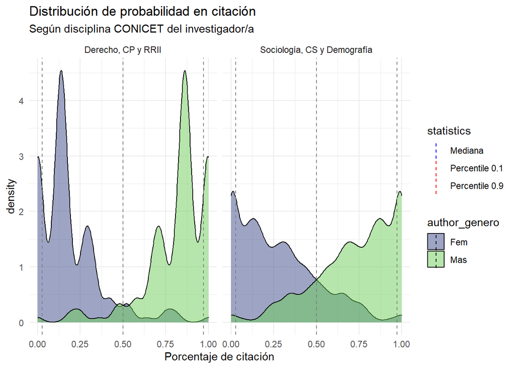

```r
##################################### DISCIPLINA

data_perc2 %>%
  ggplot(aes(x=percent, group=author_genero, fill=author_genero)) +
  geom_density(alpha=0.5) +
  facet_wrap(~disciplina) +
  scale_fill_manual(values=c("#3E4A89", "#6DCD59")) +
  labs(title = "Distribución de probabilidad en citación", x = "Porcentaje de citación",
       subtitle = "Según disciplina CONICET del investigador/a") +
  geom_vline(aes(xintercept = median(percent), color="red"), linetype="dashed", show_guide=TRUE) +
  geom_vline(aes(xintercept = quantile(percent,0.1), color="blue"), linetype="dashed", show_guide=TRUE) +
  geom_vline(aes(xintercept = quantile(percent,0.9), color="red"),linetype="dashed", show_guide=TRUE) +
  theme_minimal() +
   scale_color_manual(name = "statistics", values = c("Mediana" = "blue", "Percentile 0.1" = "red", "Percentile 0.9" = "red"))
```

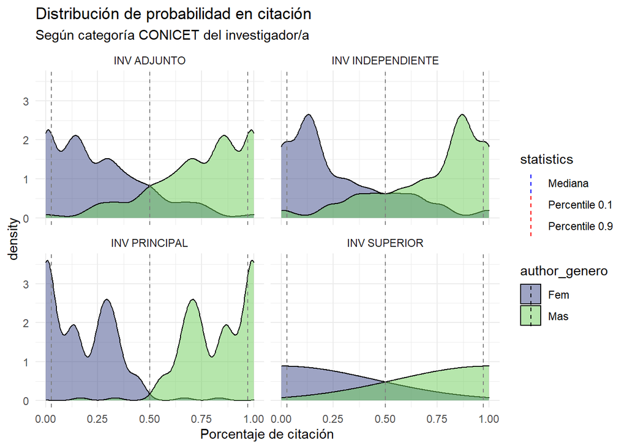

```r
##################################### CATEGORIA CONICET
data_perc3 %>%
  ggplot(aes(x=percent, group=author_genero, fill=author_genero)) +
  geom_density(alpha=0.5) +
  facet_wrap(~categoria) +
  scale_fill_manual(values=c("#3E4A89", "#6DCD59")) +
  labs(title = "Distribución de probabilidad en citación", x = "Porcentaje de citación",
       subtitle = "Según categoría CONICET del investigador/a") +
  geom_vline(aes(xintercept = median(percent), color="red"), linetype="dashed", show_guide=TRUE) +
  geom_vline(aes(xintercept = quantile(percent,0.1), color="blue"), linetype="dashed", show_guide=TRUE) +
  geom_vline(aes(xintercept = quantile(percent,0.9), color="red"),linetype="dashed", show_guide=TRUE) +
  theme_minimal() +
   scale_color_manual(name = "statistics", values = c("Mediana" = "blue", "Percentile 0.1" = "red", "Percentile 0.9" = "red"))
```

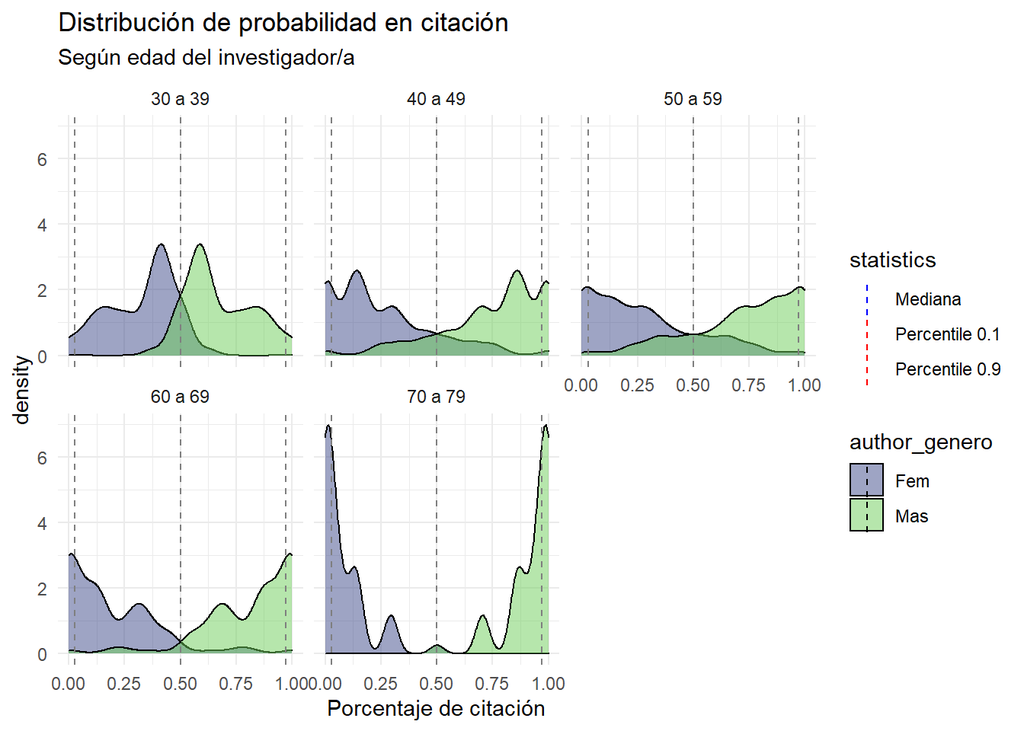

```r
##################################### EDAD AGRUPADA

data_perc4 %>%
  ggplot(aes(x=percent, group=author_genero, fill=author_genero)) +
  geom_density(alpha=0.5) +
  facet_wrap(~gruposetarios) +
  scale_fill_manual(values=c("#3E4A89", "#6DCD59")) +
  labs(title = "Distribución de probabilidad en citación", x = "Porcentaje de citación",
       subtitle = "Según edad del investigador/a") +
  geom_vline(aes(xintercept = median(percent), color="red"), linetype="dashed", show_guide=TRUE) +
  geom_vline(aes(xintercept = quantile(percent,0.1), color="blue"), linetype="dashed", show_guide=TRUE) +
  geom_vline(aes(xintercept = quantile(percent,0.9), color="red"),linetype="dashed", show_guide=TRUE) +
  theme_minimal() +
   scale_color_manual(name = "statistics", values = c("Mediana" = "blue", "Percentile 0.1" = "red", "Percentile 0.9" = "red"))
```

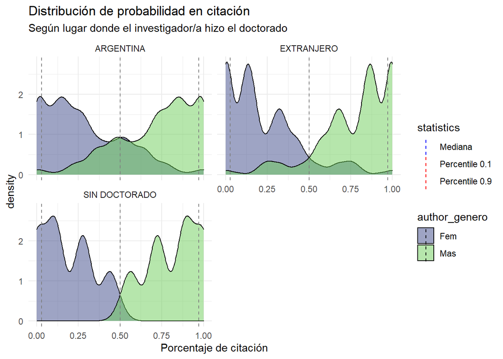

```r
##################################### LUGAR DOCTORADO
data_perc5 %>%
  ggplot(aes(x=percent, group=author_genero, fill=author_genero)) +
  geom_density(alpha=0.5) +
  facet_wrap(~Lugar, ncol = 2) +
  scale_fill_manual(values=c("#3E4A89", "#6DCD59")) +
  labs(title = "Distribución de probabilidad en citación", x = "Porcentaje de citación", subtitle = "Según lugar donde el investigador/a hizo el doctorado") +
  geom_vline(aes(xintercept = median(percent), color="red"), linetype="dashed", show_guide=TRUE) +
  geom_vline(aes(xintercept = quantile(percent,0.1), color="blue"), linetype="dashed", show_guide=TRUE) +
  geom_vline(aes(xintercept = quantile(percent,0.9), color="red"),linetype="dashed", show_guide=TRUE) +
  theme_minimal() +
   scale_color_manual(name = "statistics", values = c("Mediana" = "blue", "Percentile 0.1" = "red", "Percentile 0.9" = "red"))
```

```r
#
#))
```

# Regresión Logística I

**Y**: probabilidad de citar autoras mujeres **X1**: Género del investigador/a **X2**: Lugar donde el investigador/a hizo el PhD **X3**: Edad del investigador/a **X4**: Disciplina CONICET del investigador/a **X5**: Categoría CONICET del investigador/a **X6**: Comunidad de pertenencia del investigador/a

```r
data11 <- data11 %>%
  mutate(investigador_genero = case_when(
    investigador_genero == 1 ~ "F",
    T ~  "M"
  ))

data_reg <- data_perc %>%
  left_join(data11 %>%
               filter( author_genero != "ND") %>%
  select(id_art,
         Lugar, edad, disciplina, categoria, Comunidad) %>%
    mutate(Lugar = toupper(Lugar)))
data_reg <- data_reg[, -which(names(data_reg) %in% c("id_art", "percent"))]

modelo_logistico1 <- glm(formula = as.factor(author_genero) ~ ., data = data_reg, family = "binomial")
summary(modelo_logistico1)
```

```
##
## Call:
## glm(formula = as.factor(author_genero) ~ ., family = "binomial",
##     data = data_reg)
##
## Deviance Residuals:
##     Min       1Q   Median       3Q      Max
## -2.7388  -0.8572  -0.2107   0.9711   2.1835
##
## Coefficients:
##                                                         Estimate Std. Error
## (Intercept)                                            -3.236811   0.202923
## investigador_generoM                                   -0.205691   0.039235
## cantidad                                                0.159384   0.003090
## LugarEXTRANJERO                                        -0.175020   0.039625
## LugarSIN DOCTORADO                                     -0.269349   0.141363
## edad                                                    0.022887   0.004142
## disciplinaSociología, Comunicación Social y Demografía  0.560013   0.050860
## categoriaINV INDEPENDIENTE                             -0.096108   0.051833
## categoriaINV PRINCIPAL                                 -0.249607   0.092579
## categoriaINV SUPERIOR                                   0.592486   0.299055
## Comunidad                                               0.123015   0.011263
##                                                        z value Pr(>|z|)
## (Intercept)                                            -15.951  < 2e-16 ***
## investigador_generoM                                    -5.243 1.58e-07 ***
## cantidad                                                51.574  < 2e-16 ***
## LugarEXTRANJERO                                         -4.417 1.00e-05 ***
## LugarSIN DOCTORADO                                      -1.905  0.05673 .
## edad                                                     5.525 3.29e-08 ***
## disciplinaSociología, Comunicación Social y Demografía  11.011  < 2e-16 ***
## categoriaINV INDEPENDIENTE                              -1.854  0.06371 .
## categoriaINV PRINCIPAL                                  -2.696  0.00701 **
## categoriaINV SUPERIOR                                    1.981  0.04757 *
## Comunidad                                               10.922  < 2e-16 ***
## ---
## Signif. codes:  0 '***' 0.001 '**' 0.01 '*' 0.05 '.' 0.1 ' ' 1
##
## (Dispersion parameter for binomial family taken to be 1)
##
##     Null deviance: 22461  on 16201  degrees of freedom
## Residual deviance: 17299  on 16191  degrees of freedom
##   (120 observations deleted due to missingness)
## AIC: 17321
##
## Number of Fisher Scoring iterations: 6
```

# Regresión Logística II

**Y**: probabilidad de citar autoras mujeres **X1**: género del investigador

```r
data_reg <- data11 %>%
  filter(!is.na(author_genero) & author_genero != "ND") %>%
  select(id_art, investigador_genero, author_genero) %>%
  group_by(id_art, investigador_genero, author_genero) %>%
  dplyr::summarise(count = n()) %>%
  ungroup() %>%
  group_by(id_art) %>%
  transmute(percent = count/sum(count))
data_reg <- data_reg %>%
  left_join(data11 %>%
               filter( author_genero != "ND") %>%
  select(id_art, investigador_genero,author_genero)
  ) %>%
  mutate(author_genero = case_when(author_genero == "M" ~ 0, T~1))
data_reg <- sqldf("select * from data_reg group by id_art, investigador_genero, author_genero")


#data_reg <- data_reg[,-c(1,4)]
data_reg <- data_reg[,-c(1,2#,4
                         )]

modelo_logistico2 <- glm(formula = as.factor(author_genero) ~ ., data = data_reg, family = "binomial")
summary(modelo_logistico2)
```

```
##
## Call:
## glm(formula = as.factor(author_genero) ~ ., family = "binomial",
##     data = data_reg)
##
## Deviance Residuals:
##    Min      1Q  Median      3Q     Max
## -1.117  -1.117  -0.971   1.239   1.399
##
## Coefficients:
##                      Estimate Std. Error z value Pr(>|z|)
## (Intercept)          -0.14436    0.08406  -1.717  0.08592 .
## investigador_generoM -0.36274    0.12049  -3.010  0.00261 **
## ---
## Signif. codes:  0 '***' 0.001 '**' 0.01 '*' 0.05 '.' 0.1 ' ' 1
##
## (Dispersion parameter for binomial family taken to be 1)
##
##     Null deviance: 1552.3  on 1140  degrees of freedom
## Residual deviance: 1543.2  on 1139  degrees of freedom
## AIC: 1547.2
##
## Number of Fisher Scoring iterations: 4
```

```r
data_reg <- data11 %>%
  filter(!is.na(author_genero) & author_genero != "ND") %>%
  select(id_art, investigador_genero, author_genero) %>%
  group_by(id_art, investigador_genero, author_genero) %>%
  dplyr::summarise(count = n()) %>%
  ungroup() %>%
  group_by(id_art) %>%
  transmute(percent = count/sum(count))
data_reg <- data_reg %>%
  left_join(data11 %>%
               filter( author_genero != "ND") %>%
  select(id_art, investigador_genero,author_genero)
  ) %>%
  mutate(author_genero = case_when(author_genero == "M" ~ 0, T~1))
```

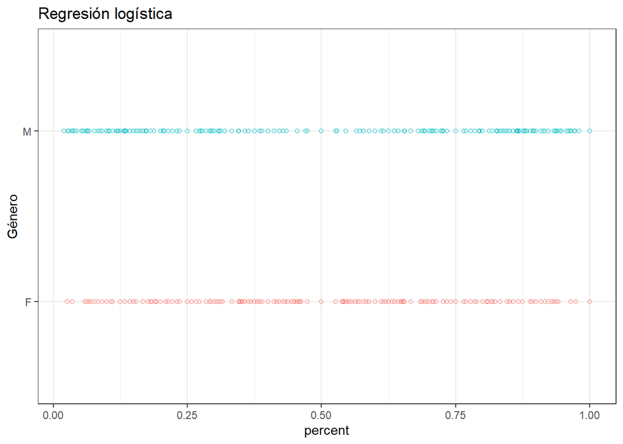

```r
ggplot(data = data_reg, aes(y = as.factor(investigador_genero), x =percent)) +
  geom_point(aes(color = as.factor(investigador_genero)), shape = 1) +
    stat_smooth(method="glm", se=FALSE, method.args = list(family=binomial)) +

  theme_bw() +
  labs(title = "Regresión logística",
       y = "Género") +
  theme(legend.position = "none")
```